# Stroke Prediction

2025-10-29

Problem Statement: Strokes are a leading cause of death and long-term disability. Early identification of individuals at elevated risk can significantly improve prevention and intervention outcomes. The goal of this project is to build a predictive model that identifies individuals who are at risk of having a stroke. I will base This model on demographic, lifestyle, and health-related predictors. The prevalence of stroke in the data set is low, around 6%, so the primary goal is to maximize sensitivity (true-positive). Because this data is of past events, we will interpret the model predicting an individual has had a stroke as indicating elevated stroke risk.

Data Description: The data set contains information on 5,110 individuals with the features age, gender, hypertension status, heart disease status, marital status, work type, residence type, average glucose level, BMI, and smoking status. The target variable, stroke, is a binary classification (0/1). Stoke is rare in the data set, creating a significant class imbalance that must be addressed during modeling.

Data Cleaning and Pre-processing: * Removal of Children and Individuals who have never worked: Children were removed from the data set. Children are not an at risk group, and I believed their inclusion in the data set was inappropriate for the purpose of predicting stroke. After removing children under 18, the never_worked level of the work_type feature was left with only 5 observational units. I also removed these individuals because the model cannot learn about a feature level with so few instances. These changes reduced the data set to 4249 observational units.

- Handling of missing BMI values: BMI had missing values. Analysis showed that individuals with missing BMI differed significantly from others in glucose levels and stroke rates. This indicated that the missingness was not random. Rather than dropping these cases, BMI was transformed into a categorical variable consisting of the levels missing, normal, overweight, and obese. These allowed for missingness to become a meaningful category.
- Train-test split: The cleaned data set was split into a training set (0.80) and a test set for modeling and final evaluation.

Exploratory Data Analysis: Stroke prevalence: Around 6% of individuals experienced a stroke, confirming a heavy class imbalance.

Age: Stroke patients are significantly older on average. An ANOVA analysis indicated a strong association between age and stroke.

Glucose Levels: Individuals with higher average glucose levels have higher stroke rates. Significant differences in average glucose levels were found between BMI groups using an ANOVA analysis.

Categorical Features: After performing Chi-squared tests, hypertension and heart disease were found to strongly correlate with stroke. Work type and smoking status also showed meaningful differences across stroke outcomes, with the formerly smoked level of smoking status in particular having a correlation with stroke. Marital status also showed a correlation.

Logistic regression provides an a good baseline, but it is limited by its linear assumptions. Two of the strongest predictiors, age and glucose, are nonlinear. This reduces performance.

Advanced Model: XGBoost XGBoost was selected as the advanced model because it handles nonlinear interactions, and is generally considred a good model for tabular medical data sets. Performance: AUC ≈ 0.82 Sensitivity ≈ 0.88 Specificity ≈ 0.65

This represents a substantial improvement over logistic regression. The model correctly indetifies 88% of stroke cases, making it well suited for risk screening where missing a high risk patient is more costly than generating false alarms. Feature importance analysis identified age, average glucose level, hypertension, BMI category, and smoking status as key drivers of stroke risk.

```r
# For this data science project I will take the stroke prediction data set from Kaggle and create a model that can accurately predict whether or not a person is at risk for a stroke. We will consider a person at risk for a stroke if the model predicts that they had a stroke.
```

```r
library(tidyverse)
```

```r
library(rpart)
library(rpart.plot)
library(randomForest)
library(caret)
library(pROC)
library(mgcv)
library(xgboost)
```

EDA

```r
df <- read.csv("healthcare-dataset-stroke-data.csv")

glimpse(df)
```

```
## Rows: 5,110
## Columns: 12
## $ id                <int> 9046, 51676, 31112, 60182, 1665, 56669, 53882, 10434…
## $ gender            <chr> "Male", "Female", "Male", "Female", "Female", "Male"…
## $ age               <dbl> 67, 61, 80, 49, 79, 81, 74, 69, 59, 78, 81, 61, 54, …
## $ hypertension      <int> 0, 0, 0, 0, 1, 0, 1, 0, 0, 0, 1, 0, 0, 0, 0, 1, 0, 1…
## $ heart_disease     <int> 1, 0, 1, 0, 0, 0, 1, 0, 0, 0, 0, 1, 0, 1, 1, 0, 1, 0…
## $ ever_married      <chr> "Yes", "Yes", "Yes", "Yes", "Yes", "Yes", "Yes", "No…
## $ work_type         <chr> "Private", "Self-employed", "Private", "Private", "S…
## $ Residence_type    <chr> "Urban", "Rural", "Rural", "Urban", "Rural", "Urban"…
## $ avg_glucose_level <dbl> 228.69, 202.21, 105.92, 171.23, 174.12, 186.21, 70.0…
## $ bmi               <chr> "36.6", "N/A", "32.5", "34.4", "24", "29", "27.4", "…
## $ smoking_status    <chr> "formerly smoked", "never smoked", "never smoked", "…
## $ stroke            <int> 1, 1, 1, 1, 1, 1, 1, 1, 1, 1, 1, 1, 1, 1, 1, 1, 1, 1…
```

```r
# 5110 observations with 11 input features.

## id:                 int
## gender:             character       -> Should be factor
## age:                double
## hypertension:       int (0/1)       -> Should be factor
## heart_disease:      int (0/1)       -> Should be factor
## ever_married:       character       -> Should be factor
## work_type:          character       -> Should be factor
## Residence_type:     character       -> Should be factor
## avg_glucose_level:  double
## bmi:                character       -> Should be numeric
## smoking_status:     character       -> Should be factor

## stroke:             int (0/1)       -> Should be factor

df$gender         <- factor(df$gender)
df$hypertension   <- factor(df$hypertension)
df$heart_disease  <- factor(df$heart_disease)
df$ever_married   <- factor(df$ever_married)
df$work_type      <- factor(df$work_type)
df$Residence_type <- factor(df$Residence_type)
df$smoking_status <- factor(df$smoking_status)
df$stroke         <- factor(df$stroke)
```

```r
summary(df)
```

```
##        id           gender          age        hypertension heart_disease
##  Min.   :   67   Female:2994   Min.   : 0.08   0:4612       0:4834
##  1st Qu.:17741   Male  :2115   1st Qu.:25.00   1: 498       1: 276
##  Median :36932   Other :   1   Median :45.00
##  Mean   :36518                 Mean   :43.23
##  3rd Qu.:54682                 3rd Qu.:61.00
##  Max.   :72940                 Max.   :82.00
##  ever_married         work_type    Residence_type avg_glucose_level
##  No :1757     children     : 687   Rural:2514     Min.   : 55.12
##  Yes:3353     Govt_job     : 657   Urban:2596     1st Qu.: 77.25
##               Never_worked :  22                  Median : 91.89
##               Private      :2925                  Mean   :106.15
##               Self-employed: 819                  3rd Qu.:114.09
##                                                   Max.   :271.74
##      bmi                    smoking_status stroke
##  Length:5110        formerly smoked: 885   0:4861
##  Class :character   never smoked   :1892   1: 249
##  Mode  :character   smokes         : 789
##                     Unknown        :1544
##
##
```

```r
# Notable:
## age: The minimum age is 0.08. That has to be an error. I need to explore age and find out how many observational units are problematic
## hypertension: 9.7 % of the observational units have hypertension.
## heart_disease: 5.4% have heart disease
## stroke: 4.9% have had a stroke. Only 5 percent of the target class is positive. This could cause issues during training.
## avg_glucose_level: The average glucose level is at a normal level for an average adult. This taken into account with the mean age, it seems like the data set is representative of average adults.
```

```r
#gender
summary(df$gender)
```

```
## Female   Male  Other
##   2994   2115      1
```

```r
table(df$gender)
```

```
##
## Female   Male  Other
##   2994   2115      1
```

```r
other <- df %>% filter(gender =="Other")
other
```

```
##      id gender age hypertension heart_disease ever_married work_type
## 1 56156  Other  26            0             0           No   Private
##   Residence_type avg_glucose_level  bmi  smoking_status stroke
## 1          Rural            143.33 22.4 formerly smoked      0
```

```r
## Other could be an interesting factor level if there were more instances, but since there is only one we will either have to delete the observational unit or convert
## to Female or Male. A quick Google search suggests that those assigned female at birth are more likely to identify as other, we will convert this unit to female

df[3117, "gender"] <- "Female"

tab <- table(df$stroke, df$gender)
tab <- tab[, colSums(tab) > 0]
chisq.test(tab)
```

```
##
##  Pearson's Chi-squared test with Yates' continuity correction
##
## data:  tab
## X-squared = 0.34313, df = 1, p-value = 0.558
```

```r
## stroke and gender are independent
```

```r
#age
summary(df$age)
```

```
##    Min. 1st Qu.  Median    Mean 3rd Qu.    Max.
##    0.08   25.00   45.00   43.23   61.00   82.00
```

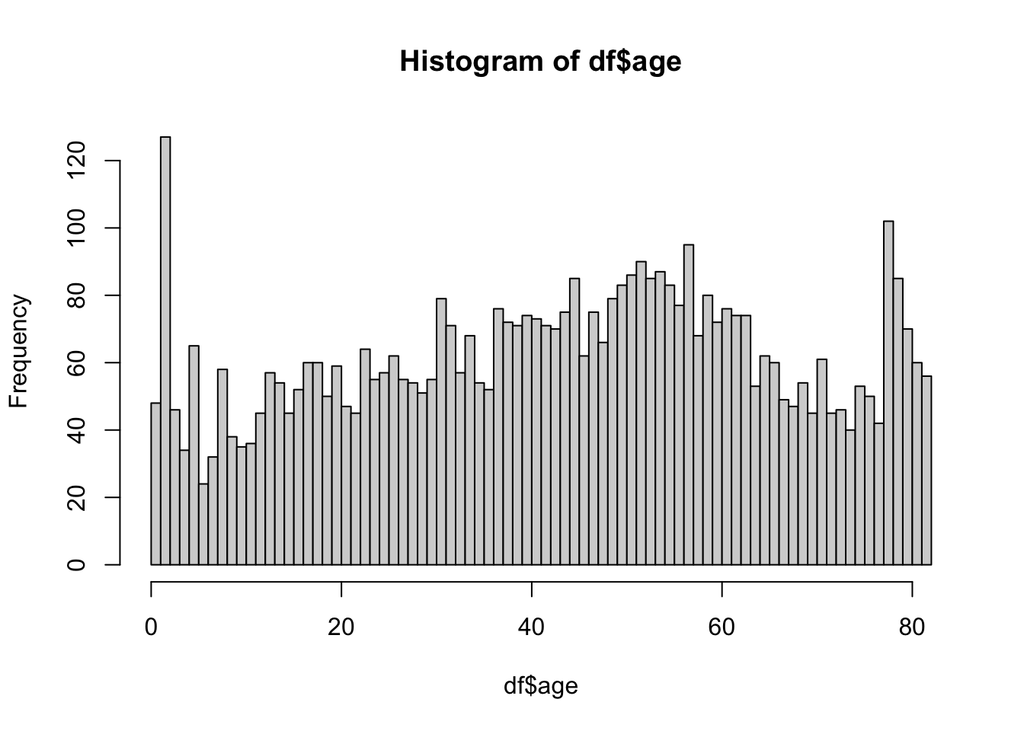

```r
hist(df$age, breaks=64)
```

```r
## Upon further investigation, the 0.08 minimum age was not a mistake, but children being included in the data set. I may end up converting age to a factor, and decimals
## are an issue. Apart from that issue, there is also the fact that children are not an at risk group for stroke, and there inclusion will affect the accuracy of the model.
## I believe the best course of action would be to remove the children all together, but I need to by which marker I am removing them. I could remove everyone with the occupation level of "children" or I could remove everyone under 18. I do not yet know if those completely overlap.

children <- df %>% filter(work_type == "children")
eighteen <- df %>% filter(age < 18)

## "children" =/= < 18
## I will remove everyone under the age of 18.

df <- df[df$age >= 18, ]

## New observational unit count is 4254. 5110-4254 = 856
## We removed 856 observational units.

## summary before:
##   Min.   1st Qu.  Median   Mean    3rd Qu.   Max.
##   0.08   25.00    45.00    43.23   61.00     82.00

##
##   Min.   1st Qu.  Median   Mean    3rd Qu.   Max.
##   18.0   36.0     50.5     50.2    64.0      82.0

## This is a good range and distribution

anova_model <- aov(age ~ stroke, data=df)
summary(anova_model)
```

```
##               Df  Sum Sq Mean Sq F value Pr(>F)
## stroke         1   85078   85078   285.6 <2e-16 ***
## Residuals   4252 1266842     298
## ---
## Signif. codes:  0 '***' 0.001 '**' 0.01 '*' 0.05 '.' 0.1 ' ' 1
```

```r
## stroke and age are not independent.
```

```r
# work_type, residence, ever_married

table(df$work_type)
```

```
##
##      children      Govt_job  Never_worked       Private Self-employed
##             0           651             5          2791           807
```

```r
N_Worked <- df %>% filter(work_type=="Never_worked")

## After removing children:
## Govt_job   Never_worked   Private    Self-employed
## 651        5              2791       807

## Never_worked only has 5 instances. This is too few for our model to learn on, and at this level it will only be noise. I will remove those observational units.

df <- df %>% filter(work_type != "Never_worked")


table(df$Residence_type)
```

```
##
## Rural Urban
##  2085  2164
```

```r
## There is a roughly even ratio of Rural to Urban.

table(df$ever_married)
```

```
##
##   No  Yes
##  896 3353
```

```r
## There 3.74 individuals who have been married at least once to ever individual who has never been married. This makes sense.

tab <- table(df$stroke, df$work_type)
tab <- tab[, colSums(tab) > 0]
chisq.test(tab)
```

```
##
##  Pearson's Chi-squared test
##
## data:  tab
## X-squared = 9.2108, df = 2, p-value = 0.009998
```

```r
## work_type and stroke are not independent

tab <- table(df$stroke, df$Residence_type)
tab <- tab[, colSums(tab) > 0]
chisq.test(tab)
```

```
##
##  Pearson's Chi-squared test with Yates' continuity correction
##
## data:  tab
## X-squared = 1.0208, df = 1, p-value = 0.3123
```

```r
##stroke and Residence_type are independent

tab <- table(df$stroke, df$ever_married)
tab <- tab[, colSums(tab) > 0]
chisq.test(tab)
```

```
##
##  Pearson's Chi-squared test with Yates' continuity correction
##
## data:  tab
## X-squared = 15.614, df = 1, p-value = 7.769e-05
```

```r
##stroke and ever_married are not independent
```

```r
#avg_glucose_level

summary(df$avg_glucose_level)
```

```
##    Min. 1st Qu.  Median    Mean 3rd Qu.    Max.
##   55.12   77.46   92.49  108.53  116.14  271.74
```

```r
sum(is.na(df$avg_glucose_level))
```

```
## [1] 0
```

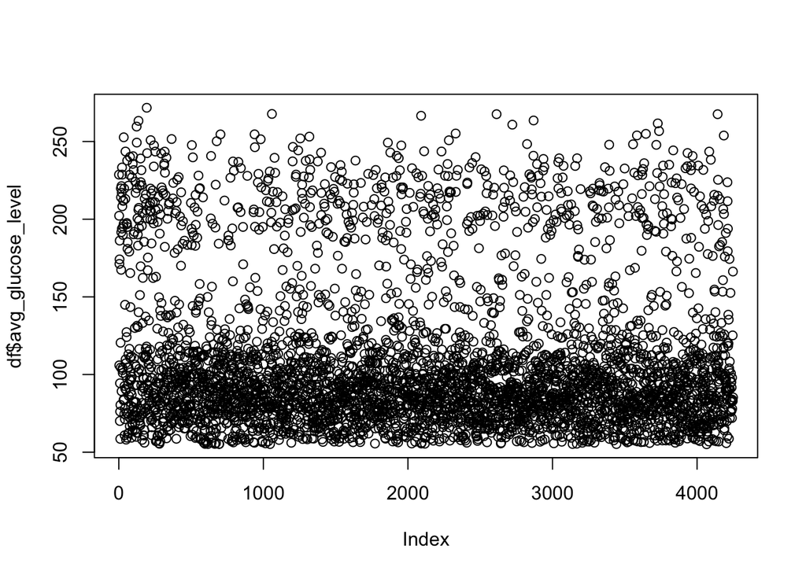

```r
plot(df$avg_glucose_level)
```